# Week 11 - Correlation, simple & multiple regression

#### Recall: Power law model

The form of the power law relationship is $y = C \times x^\theta$.

The statistical model we will actually fit is going to use a log10 transformation of the power law relationship in order to make the form linear:
$$\begin{align*}
y_i = \log10(m_i) & = \log10(C) + \theta\log10(r_i) + \varepsilon_i
\\
& = \log10(C) + \theta x_i + \varepsilon_i, i = 1, \ldots, n.
\end{align*}$$
In this model, the response variable $y_i = \log10(m_i)$ is the $\log10$(mass) for exoplanet $i$, the explanatory variable $x_i = \log10(r_i)$ is the $\log10$(radius) for exoplanet $i$, $\log10(C)$ is the (unknown) intercept, $\theta$ is the (unknown) slope, and $\varepsilon_i$ is the random error for exoplanet $i$.

- Fit the model:

```r
lm1 <- lm(log10(mass) ~ log10(radius), data = mr)
summary(lm1)
```

```
##
## Call:
## lm(formula = log10(mass) ~ log10(radius), data = mr)
##
## Residuals:
##      Min       1Q   Median       3Q      Max
## -1.22237 -0.19972 -0.01809  0.17894  1.70979
##
## Coefficients:
##               Estimate Std. Error t value Pr(>|t|)
## (Intercept)    0.60834    0.02913   20.88   <2e-16 ***
## log10(radius)  1.09983    0.04763   23.09   <2e-16 ***
## ---
## Signif. codes:  0 '***' 0.001 '**' 0.01 '*' 0.05 '.' 0.1 ' ' 1
##
## Residual standard error: 0.3297 on 450 degrees of freedom
## Multiple R-squared:  0.5424, Adjusted R-squared:  0.5413
## F-statistic: 533.3 on 1 and 450 DF,  p-value: < 2.2e-16
```

```r
## Add residuals and predicted values to our data frame
mr <- mr %>%
  add_residuals(lm1) %>%
  add_predictions(lm1)
```

The estimated intercept is 0.608 and the estimated slope is 1.1.

#### Prediction

Let’s take a look at our estimated model on a plot again:

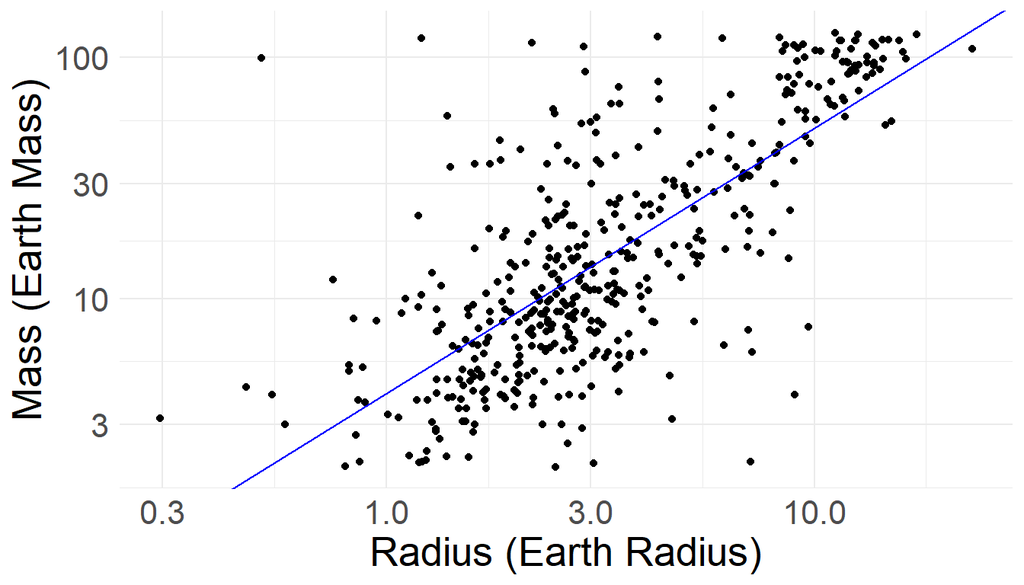

```r
ggplot(mr, aes(radius, mass)) +
  geom_point() +
  xlab("Radius (Earth Radius)") +
  ylab("Mass (Earth Mass)") +
  scale_x_log10() +
  scale_y_log10() +
  geom_abline(aes(slope = coef(lm1)[2] , intercept = coef(lm1)[1]), color="blue") +
  theme(text = element_text(size=20))
```

The estimated regression model is
$$\hat{y}_i = 0.608 + 1.1 x_i.$$

We can use the estimated linear model to predict a mass for a given radius.

Note that the function below assumes the input `x` is radius on the original scale and returns an estimated mass on the original scale.

```r
predict_y <- function(x){
    ## x = radius (on original scale)
    slope <- coef(lm1)[2]
    intercept <- coef(lm1)[1]
    logy <- intercept + slope*log10(x)
    y <- 10^logy
    names(y) <- "predicted mass"
    return(y)
}

radius_input <- 3
mass_predicted <- predict_y(3)
mass_predicted
```

```
## predicted mass
##       13.58621
```

We can plot this point as well:

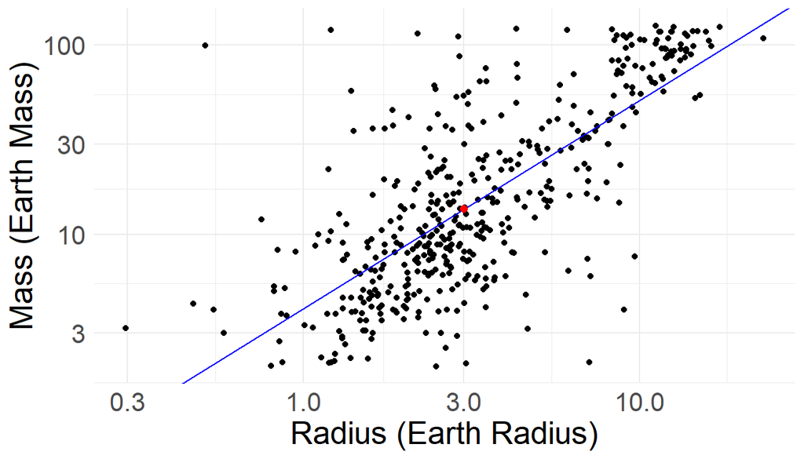

```r
ggplot(mr, aes(radius, mass)) +
  geom_point() +
  xlab("Radius (Earth Radius)") +
  ylab("Mass (Earth Mass)") +
  scale_x_log10() +
  scale_y_log10() +
  geom_abline(aes(slope = coef(lm1)[2] , intercept = coef(lm1)[1]), color="blue") +
  geom_point(aes(x = radius_input, y=mass_predicted), color = "red", size = 2) +
  theme(text = element_text(size=20))
```

An interesting and useful feature of the least squares regression line is that it goes through the point $(\bar{x}, \bar{y})$. We can check this with our function as well.

- This property holds on the scale of the linear model.
- Since our $x$ and $y$ variables were transformed, we have to make some adjustments to the scale.

```r
radius <- 10^mean(log10(mr$radius)) ## mean of log10(radius), transformed back to original scale for function
radius
```

```
## [1] 3.295109
```

```r
log10(predict_y(radius)) ## predicted value at xbar
```

```
## predicted mass
##       1.177915
```

```r
print(paste0("(xbar,ybar) = (",round(mean(log10(mr$radius)),3), ", ", round(mean(log10(mr$mass)),3),")"))
```

```
## [1] "(xbar,ybar) = (0.518, 1.178)"
```

We can get our predicted values of mass, but there is uncertainty in this estimate, and it can be desirable to define an interval around the estimate to capture this uncertainty.

There are two common ways to look at this problem of predicting $\hat{y}$:

- Confidence interval
  - The goal is an uncertainty interval around the parameter $E(y \mid x^*)$, the expected value of the response given the explanatory variable $x^*$.
- Prediction interval
  - The goal is an uncertainty interval around some future $y^*$ for some given $x^*$.
  - The prediction interval is trying to capture a *random* outcome $y^*$ rather than a fixed parameter like the $E(y \mid x^*)$.

We will focus on the confidence interval version next.

# Confidence intervals for $E(y \mid x^*)$

The goal is an uncertainty interval around the parameter $E(y \mid x^*)$, the expected value of the response given the explanatory variable $x^*$.

The uncertainty in the estimated $\hat{y}$ needs to account for the uncertainty in the estimated intercept and estimated slope. The formula for this uncertainty is
$$s_{\hat{y}} = \sqrt{\left((n-2)^{-1} \sum_{i=1}^n(y_i -
\hat{y}_i)^2\right)\left(n^{-1} + \frac{(x^* - \overline{x})^2}{\sum_{i
= 1}^n (x_i - \overline{x})^2} \right)}$$

where $x^*$ is the radius (on the original scale) for which the confidence interval of $E(y \mid x^*)$ is desired.

We can write a function to compute $s_{\hat{y}}$:

```r
s_yhat <- function(x){
  ## x = radius on original scale
  n <- nrow(mr)
  syy <- sum(mr$resid^2)/(n-2)
  mean_logx <-mean(log10(mr$radius))
  sxx <- sum((log10(mr$radius) - mean_logx)^2)
  out <- sqrt(syy*(1/n + (log10(x)-mean_logx)^2/sxx))
  return(out)
}

s_yhat(3)
```

```
## [1] 0.01562742
```

Next we add the lower and upper bounds for 95% confidence interval to `mr`, then add them to our plot.

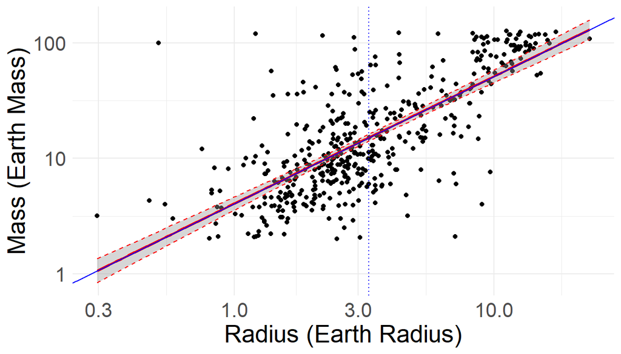

```r
n <- nrow(mr)
mr <- mr %>%
  mutate(y_plus_se = pred + qt(.975, n-2)*s_yhat(radius),
         y_minus_se = pred - qt(.975, n-2)*s_yhat(radius))

ggplot(mr, aes(radius, mass)) +
  geom_point() +
  xlab("Radius (Earth Radius)") +
  ylab("Mass (Earth Mass)") +
  scale_x_log10() +
  scale_y_log10() +
  geom_smooth(method="lm", se=TRUE, color="red")+
  geom_abline(aes(slope = coef(lm1)[2] , intercept = coef(lm1)[1]), color="blue") +
  geom_line(aes(x = radius, y= 10^y_plus_se), color = "red", linetype="dashed") +
  geom_line(aes(x = radius, y= 10^y_minus_se), color = "red", linetype="dashed") +
  geom_vline(aes(xintercept = 10^(mean(log10(radius)))), color="blue", linetype="dotted") +
  theme(text = element_text(size=20))
```

Notice that our 95% confidence interval outlines the shaded region when we use `geom_smooth(method="lm", se=TRUE)`!

It is subtle in the plot, but confidence interval narrows as $x^*$ gets closer to the mean of the $\log10$(radius).

- See the vertical dotted blue line above for the location of this mean.
- The formula for $s_{\hat{y}}$ reveals why this happens.

# Prediction Intervals for random $y^*$

- The goal is an uncertainty interval around some future $y^*$ for some given $x^*$.
- The prediction interval is trying to capture a *random* outcome $y^*$ rather than a fixed parameter like the $E(y \mid x^*)$.

The uncertainty in some *random* outcome $y^*$ needs to account for the uncertainty in the estimated intercept and estimated slope, but also the uncertainty related to the randomness of the outcome (from the $\varepsilon^*$ associated with $y^*$).

The formula for this uncertainty is
$$s_{\hat{y}^*} = \sqrt{\left((n-2)^{-1} \sum_{i=1}^n(y_i -
\hat{y}_i)^2\right)\left(1 + n^{-1} + \frac{(x^* -
\overline{x})^2}{\sum_{i = 1}^n (x_i - \overline{x})^2} \right)}$$

where $x^*$ is the radius (on the original scale) that is associated with $\hat{y}^*$.

We can write a function to compute $s_{\hat{y}}$:

```r
s_yhatstar <- function(x){
  ## x = radius on original scale
  n <- nrow(mr)
  syy <- sum(mr$resid^2)/(n-2)
  mean_logx <-mean(log10(mr$radius))
  sxx <- sum((log10(mr$radius) - mean_logx)^2)
  out <- sqrt(syy*(1 + 1/n + (log10(x)-mean_logx)^2/sxx))
  return(out)
}

s_yhatstar(3)
```

```
## [1] 0.3300418
```

Next we add the lower and upper bounds for 95% prediction interval to `mr`, then add them to our plot

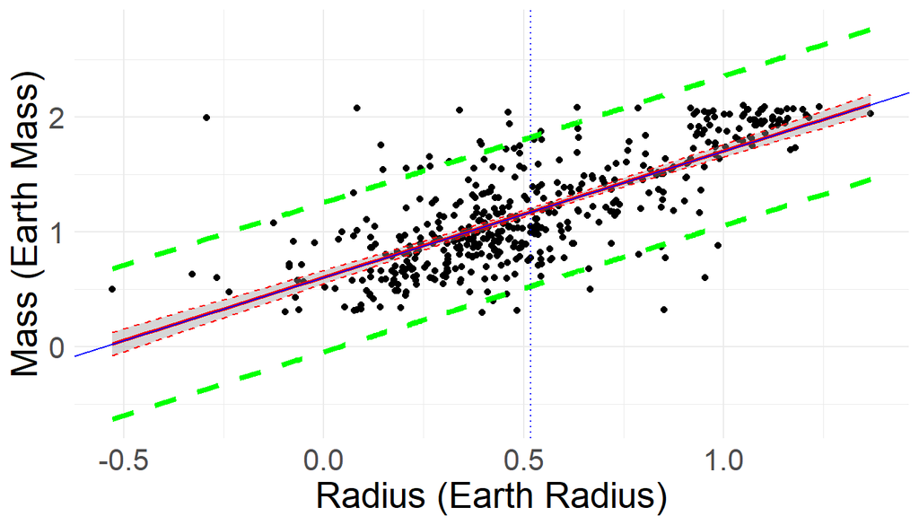

```r
n <- nrow(mr)
mr <- mr %>%
  mutate(ystar_plus_se = pred + qt(.975, n-2)*s_yhatstar(radius),
         ystar_minus_se = pred - qt(.975, n-2)*s_yhatstar(radius))

ggplot(mr, aes(log10(radius), log10(mass))) +
  geom_point() +
  xlab("Radius (Earth Radius)") +
  ylab("Mass (Earth Mass)") +
  #scale_x_log10() +
  #scale_y_log10() +
  geom_line(aes(x = log10(radius), y= ystar_plus_se), color = "green", linetype="dashed", size= 1.5) +
  geom_line(aes(x = log10(radius), y= ystar_minus_se), color = "green", linetype="dashed", size= 1.5) +
  geom_smooth(method="lm", se=TRUE, color="red")+
  geom_abline(aes(slope = coef(lm1)[2] , intercept = coef(lm1)[1]), color="blue") +
  geom_line(aes(x = log10(radius), y= y_plus_se), color = "red", linetype="dashed") +
  geom_line(aes(x = log10(radius), y= y_minus_se), color = "red", linetype="dashed") +
  geom_vline(aes(xintercept = (mean(log10(radius)))), color="blue", linetype="dotted") +
  theme(text = element_text(size=20))
```

Notice the 95% prediction interval (green dashed lines) is wider than the 95% confidence interval.

# Multiple regression model

- Previously we learned about linear regression when there is a response variable $Y$ and a single predictor variable $X$.
- More generally, you will encounter settings where there are multiple predictor variables $X_1$, $X_2$, …, $X_p$.
- In this setting, the linear model can be written as

$$Y_i = \beta_0 + \beta_1 X_{1i} + \cdots + \beta_pX_{pi} + \varepsilon_i$$
The intercept $\beta_0$ and slope parameters $\beta_1, \ldots, \beta_p$ can be estimated using the method of least squares.

We will use this model to predict finishing times of the runners in the 2013 Boston Marathon who were not able to finish due to the bombings.

# Recall: Background on the Boston Marathon

- The Boston Marathon is the world’s oldest annual marathon competition
- A marathon is a 26.2 mile (42.2 km) running race
- The Boston Marathon is an annual marathon that usually occurs in April, and is organized by the Boston Athletic Association
- The first Boston Marathon took place on April 19, 1897
- To run in the Boston Marathon, one must complete a marathon with a qualifying time within a particular time
- In 2013 the Boston Marathon took place on April 15; two bombs placed near the finish line exploded at 2:49 PM resulting in three deaths and several hundred injuries
- Of less importance, 5,756 runners failed to finish the race

> Question: The Boston Athletic Association (BAA) desired a procedure for projecting finishing times for the runners who could not complete the race in 2013 due to the bombings.

We are going to work toward predicting the finishing times for those runners failed to finish the race.

To begin, we will look at some Boston Marathon data and do a little exploratory data analysis (EDA).

### Understanding the data

- The data can be found at https://rls.sites.oasis.unc.edu/boston.html
- The Readme.pdf file explains the variables in the *TIM.txt* file we will be working with.
- The initial analysis of this data set is summarized in a paper titled [*Completing the Results of the 2013 Boston Marathon*](https://journals.plos.org/plosone/article?id=10.1371/journal.pone.0093800) by Hammerling et al (2014) in PLOS ONE.

The file TIM.txt contains the full data set for all 69,923 runners for 2013, 2011, 2010 combined.

The variables included in this file are:

- BibNum: Bib number
- Year: which year the participant ran the race (2013, 2011 or 2010)
- Age: Age on race day
- Gender1F2M: =1 if the participant was female, =2 if male
- StartHr, StartMin: 2013 participants only: the exact time the participant crossed the start line (StartHr is the hour, StatMin is minutes including decimal parts of a minute). This information will be used in some analyses to determine whether it was possible for the runner to have crossed the finish line before the bombs went off at 2:49 pm.
- K0-5, K5-10, through K40-Fin: Split time in decimal minutes for 5 km segments of the race plus a final shorter segment
- HalfMar: Split time at half marathon
- Age2014: For 2013 entrants, age on 4/21/2014 (date of next Boston marathon)

#### Read in the data file

- Read in the data file
- Adjust the following variables:
- `bib` = `BibNum` and make it a character type
- `year` = `Year`
- `age` = `Age`
- `sex` = `Gender1F2M`, change 1 to F and 2 to M

```r
bm <- read_table("../../data/TIM.txt",
                col_types = cols(.default = col_double())) %>%
  rename(bib = BibNum,
         year = Year,
         age = Age,
         sex = Gender1F2M) %>%
  mutate(bib = as.character(bib),
         sex = case_when(
           sex == 1 ~ "F",
           sex == 2 ~ "M"
         )) %>%
   mutate(final = pmap_dbl(select(., starts_with("K")), sum))
```

> How many runners in each year?

```r
# how many observations in each year?
bm %>%
  count(year)
```

```
## # A tibble: 3 × 2
##    year     n
##   <dbl> <int>
## 1  2010 22670
## 2  2011 23913
## 3  2013 23340
```

- The number of runners is fairly consistent among our three years of observations.
- The 2012 Boston Marathon is not included in the analysis because it was a particularly hot year.

> Big picture and overall goals
- We ultimately want to predict the finishing times of racers from 2013 who could not complete the marathon due to the bombings
- We have data on racers from the 2010 and 2011 Boston Marathons that we can use for this
- One idea will be to use a subset of the runners from 2010 and 2011 who are similar to the runners from 2013 who did not finish to build a model for the prediction
- We will explore features of the data by year to assess if the 2010/2011 runners are similar enough to the 2013 runners so that we can build a model using the 2010/2011 results in order to predict the 2013 results.

> Explore the Boston Marathon data

#### Side-by-side box plots of the finishing times by `sex`

```r
bm %>%
  group_by(year, sex) %>%
  summarize(med = median(final, na.rm=TRUE)) %>%
  pivot_wider(id_cols=year, names_from=sex, values_from=med)
```

```
## # A tibble: 3 × 3
## # Groups:   year [3]
##    year     F     M
##   <dbl> <dbl> <dbl>
## 1  2010  234.  215.
## 2  2011  235.  214.
## 3  2013  221.  202.
```

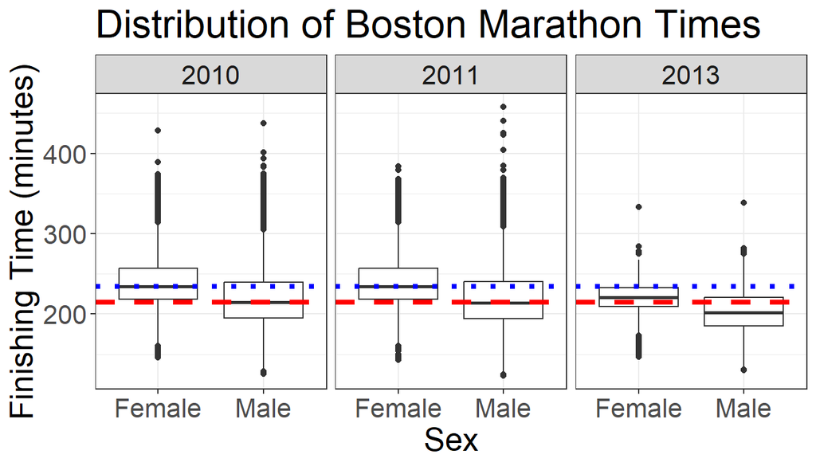

```r
ggplot(bm, aes(x=sex, y=final)) +
  geom_boxplot() +
  facet_wrap(~year) +
  scale_x_discrete(breaks=c("F","M"),
        labels=c("Female", "Male")) +
  xlab("Sex") +
  ylab("Finishing Time (minutes)") +
  ggtitle("Distribution of Boston Marathon Times") +
  geom_hline(yintercept = 215, color="red",linetype="dashed",size=1.5) +
  geom_hline(yintercept = 234, color="blue",linetype="dotted",size=1.5) +
  theme_bw() +
  theme(text = element_text(size=20))
```

- The distributions of finishing times between 2010 and 2011 are similar, but there is a clear difference compared to the 2013 finishing times  
  – This is because the 2013 finishing times include only the runners who finished before the bombs went off
- The median overall time for females is slower than the median overall time for males.
- There are some outlier points both on the fast and slow ends of the distributions, but there is a longer tail toward the slower finishing times. The range of the extremes is wider for the male runners; that is, the male runners had the fastest and the slowest final times.

#### Distribution of the age of runners on race day (violin plots)

```r
bm %>%
  group_by(year) %>%
  summarize(min = min(age), mean = mean(age), max = max(age))
```

```
## # A tibble: 3 × 4
##    year   min  mean   max
##   <dbl> <dbl> <dbl> <dbl>
## 1  2010    18  41.3    81
## 2  2011    18  41.5    81
## 3  2013    18  42.0    83
```

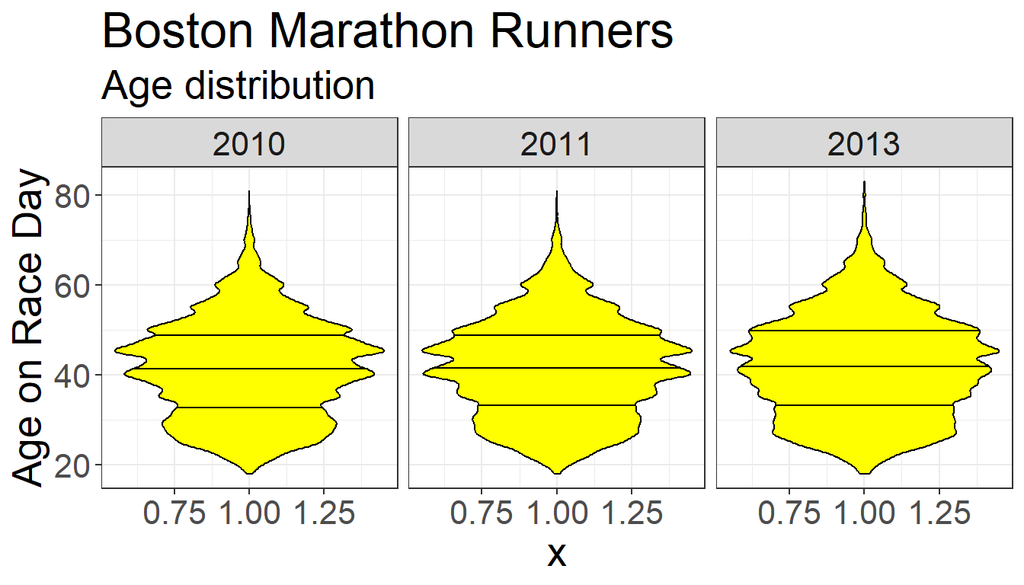

```r
## Distribution of Ages
ggplot(bm) +
  geom_violin(aes(y=age, x= 1),
                     color="black",fill="yellow",
              draw_quantiles = c(0.25, 0.5, 0.75),
              adjust = .5) +
  facet_wrap(~year) +
  ylab("Age on Race Day") +
  # xlab("Number of Runners") +
  ggtitle("Boston Marathon Runners",
          subtitle = "Age distribution") +
  theme_bw() +
  theme(text = element_text(size=20))
```

- The youngest runners were 18 years old, the average ages were around 41, and the oldest runners were 81-83

#### Distribution of the age of runners by sex on race day (box plots)

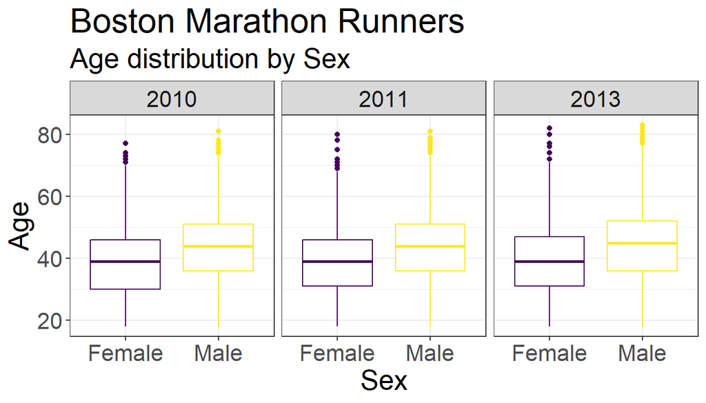

```r
ggplot(bm, aes(x=sex, y=age, color = sex)) +
  geom_boxplot(show.legend = FALSE) +
  scale_x_discrete(breaks=c("F","M"),
        labels=c("Female", "Male")) +
  xlab("Sex") +
  ylab("Age") +
    ggtitle("Boston Marathon Runners",
          subtitle = "Age distribution by Sex") +
  facet_wrap(~year) +
  theme_bw() +
  theme(text = element_text(size=20))
```

- The median female runner age was younger than the median male runner age.
- The extreme ages appear similar between the male and female runners.

#### Visualize the finishing times by age

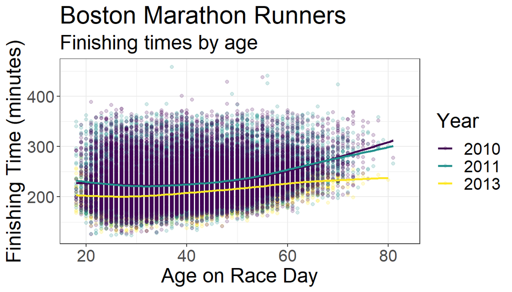

```r
bm %>%
ggplot(aes(x=age, y=final, color=as.character(year))) +
  geom_point(alpha=.2) +
  geom_smooth(se=FALSE) +
  xlab("Age on Race Day") +
  ylab("Finishing Time (minutes)") +
  ggtitle("Boston Marathon Runners",
          subtitle = "Finishing times by age") +
  labs(color="Year") +
  theme_bw() +
  theme(text = element_text(size=20))
```

- Observe that the smooth curves for 2010 and 2011 are similar, but the 2013 curve is systematically lower suggesting faster finishing times.

# Boston Runner Profiles

- Ultimately we want to predict the finishing times for the runners who did not complete the marathon in 2013 due to the bombings.
- We will explore the runner profiles.
- The runner profiles indicate the split times for the runners as they move through the course.
- The split times are provided in 5 KM intervals (except for the final 2.2 KM stretch)

First we need to get the split interval labels in a form that is easier for plotting and keeps the splits in the correct sequence.

```r
bm_long <- bm %>%
  pivot_longer(cols= starts_with("K"), names_to="split", values_to="split_time", names_prefix="K") %>%
  separate(split, c("split_start","split_end")) %>%
  mutate(split_start = as.numeric(split_start),
         split_end = as.numeric(split_end))
bm_long
```

```
## # A tibble: 629,307 × 12
##    bib    year   age sex   StartHr StartMin HalfMar Age2014 final split_start
##    <chr> <dbl> <dbl> <chr>   <dbl>    <dbl>   <dbl>   <dbl> <dbl>       <dbl>
##  1 27040  2013    27 M           9     18.1      NA      28    NA           0
##  2 27040  2013    27 M           9     18.1      NA      28    NA           5
##  3 27040  2013    27 M           9     18.1      NA      28    NA          10
##  4 27040  2013    27 M           9     18.1      NA      28    NA          15
##  5 27040  2013    27 M           9     18.1      NA      28    NA          20
##  6 27040  2013    27 M           9     18.1      NA      28    NA          25
##  7 27040  2013    27 M           9     18.1      NA      28    NA          30
##  8 27040  2013    27 M           9     18.1      NA      28    NA          35
##  9 27040  2013    27 M           9     18.1      NA      28    NA          40
## 10 27041  2013    26 M           9     18.1      NA      27    NA           0
## # ℹ 629,297 more rows
## # ℹ 2 more variables: split_end <dbl>, split_time <dbl>
```

##### Pick a runner and plot the runner’s pace across splits

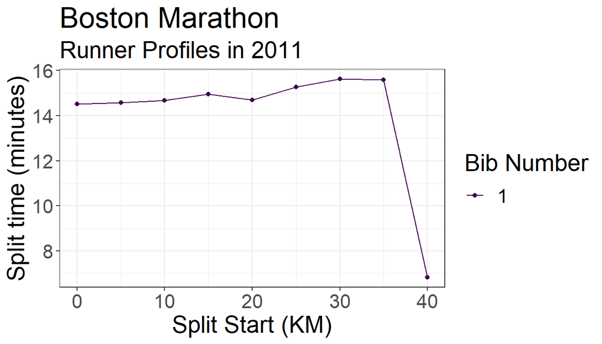

```r
runners <- c(1)
year_bib = 2011

bm_long %>%
  # filter(split_start < 40 ) %>%
  filter(year==year_bib, bib %in% runners) %>%
  ggplot(aes(x=split_start, y=split_time, color=bib)) +
  geom_point() +
  geom_line() +
  xlab("Split Start (KM)") +
  ylab("Split time (minutes)") +
  labs(color="Bib Number") +
  ggtitle("Boston Marathon",
          subtitle = str_c("Runner Profiles in ", year_bib)) +
  theme_bw() +
  theme(text = element_text(size=20))
```

- The final leg of the race is only 2.2 KM compared to 5 KM for the other legs, which contributes to why we see a significant drop with the final point.
- We can remove the final leg from the plot to improve the visualization

##### More runner profiles

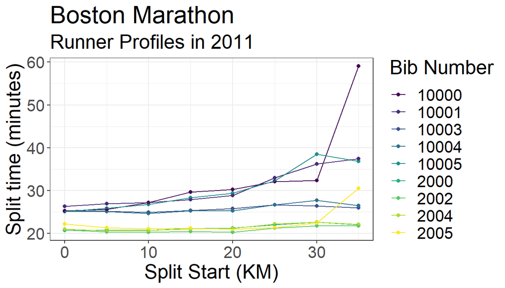

```r
runners <- c(2000:2005, 10000:10005)

bm_long %>%
  filter(split_start < 40 ) %>%
  filter(year==year_bib, bib %in% runners) %>%
  ggplot(aes(x=split_start, y=split_time, color=bib)) +
  geom_point() +
  geom_line() +
  xlab("Split Start (KM)") +
  ylab("Split time (minutes)") +
  labs(color="Bib Number") +
  ggtitle("Boston Marathon",
          subtitle = str_c("Runner Profiles in ", year_bib)) +
  theme_bw() +
  theme(text = element_text(size=20))
```

##### Next we look at the average split times by sex for the runners.

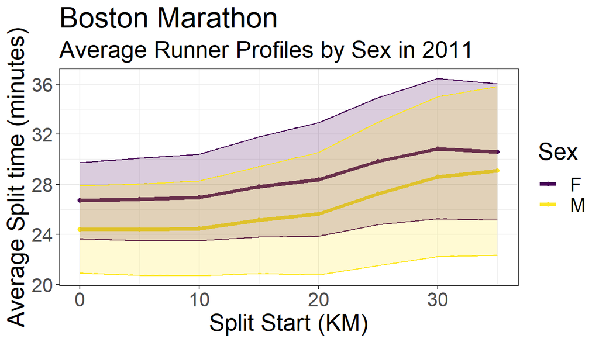

```r
bm_long %>%
  filter(split_start < 40, year==year_bib) %>%
  group_by(sex, split_start) %>%
  summarize(mean = mean(split_time), sd = sd(split_time)) %>%
  ggplot(aes(x=split_start, y=mean, color = sex)) +
  geom_point() +
  geom_line(size = 1.5) +
  geom_line(aes(y=mean+sd),linetype="dashed") +
  geom_line(aes(y=mean-sd),linetype="dashed") +
  geom_ribbon(aes(ymin=mean-sd,ymax=mean+sd, fill=sex), alpha=0.2, show.legend = FALSE) +
  xlab("Split Start (KM)") +
  ylab("Average Split time (minutes)") +
  labs(color="Sex") +
  ggtitle("Boston Marathon",
          subtitle = str_c("Average Runner Profiles by Sex in ", year_bib)) +
  theme_bw() +
  theme(text = element_text(size=20))
```

Next, plot the average split times by year and by sex.

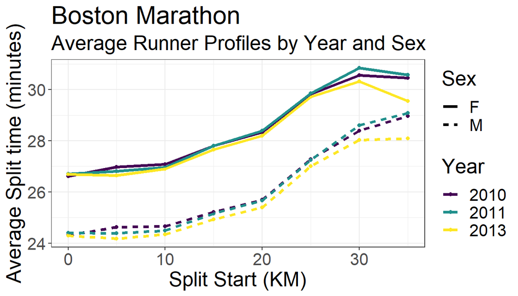

```r
bm_long %>%
  filter(split_start < 40 ) %>%
  group_by(year, sex, split_start) %>%
  summarize(mean = mean(split_time, na.rm=TRUE), sd = sd(split_time, na.rm=TRUE)) %>%
  ggplot(aes(x=split_start, y=mean, color = as.character(year), linetype=sex)) +
  geom_point() +
  geom_line(size = 1.25) +
  xlab("Split Start (KM)") +
  ylab("Average Split time (minutes)") +
  labs(color="Year", linetype = "Sex") +
  ggtitle("Boston Marathon",
          subtitle = "Average Runner Profiles by Year and Sex")+
  theme_bw() +
  theme(text = element_text(size=20))
```

Add +/- standard deviations bands for the Female runners

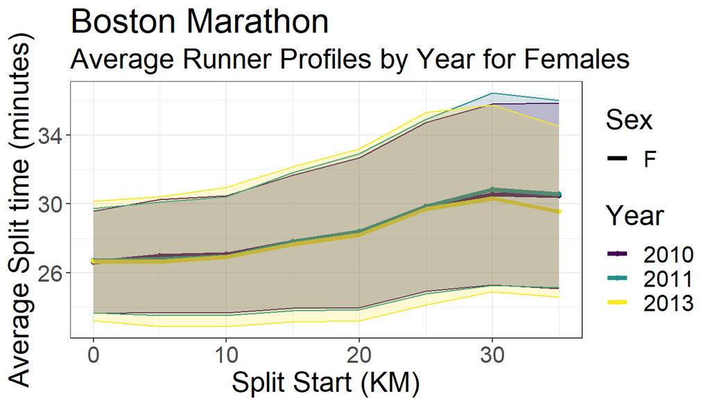

```r
bm_long %>%
  filter(split_start < 40 ) %>%
  group_by(year, sex, split_start) %>%
  filter(sex == "F") %>%
  summarize(mean = mean(split_time, na.rm=TRUE), sd = sd(split_time, na.rm=TRUE)) %>%
  ggplot(aes(x=split_start, y=mean, color = as.character(year), linetype=sex)) +
  geom_point() +
  geom_line(size = 1.5) +
  geom_ribbon(aes(ymin=mean-sd,ymax=mean+sd, fill=year), alpha=0.2, show.legend = FALSE) +
  xlab("Split Start (KM)") +
  ylab("Average Split time (minutes)") +
  labs(color="Year", linetype = "Sex") +
  ggtitle("Boston Marathon",
          subtitle = "Average Runner Profiles by Year for Females") +
  theme_bw() +
  theme(text = element_text(size=20))
```

Add +/- standard deviations bands for the Male runners

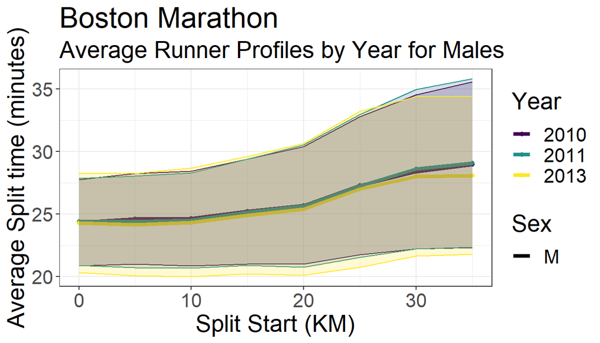

```r
bm_long %>%
  filter(split_start < 40 ) %>%
  group_by(year, sex, split_start) %>%
  filter(sex == "M") %>%
  summarize(mean = mean(split_time, na.rm=TRUE), sd = sd(split_time, na.rm=TRUE)) %>%
  ggplot(aes(x=split_start, y=mean, color = as.character(year), linetype=sex)) +
  geom_point() +
  geom_line(size = 1.5) +
  geom_ribbon(aes(ymin=mean-sd,ymax=mean+sd, fill=year), alpha=0.2, show.legend = FALSE) +
  xlab("Split Start (KM)") +
  ylab("Average Split time (minutes)") +
  labs(color="Year", linetype = "Sex") +
  ggtitle("Boston Marathon",
          subtitle = "Average Runner Profiles by Year for Males") +
  theme_bw() +
  theme(text = element_text(size=20))
```

- When reviewing the average runner profiles, there is quite a lot of variability around the means.

# Selecting our data for prediction

- Recall that we want to predict the finishing times among the 5,756 runners who were not able to complete the 2013 race due to the bombings.
- We need to identify the runners who did not complete the race due to the bombings, so we’ll need a few extra points of information.
- Runners start the marathon in waves, and the third and final wave started at 10:40 AM.
- The bombs went off at 2:49 PM.

```r
## Find latest recorded start time from 2013
bm %>%
  filter(year == 2013) %>%
  arrange(desc(StartHr), desc(StartMin))
```

```
## # A tibble: 23,340 × 18
##    bib    year   age sex   StartHr StartMin `K0-5` `K5-10` `K10-15` `K15-20`
##    <chr> <dbl> <dbl> <chr>   <dbl>    <dbl>  <dbl>   <dbl>    <dbl>    <dbl>
##  1 22980  2013    39 M          10     53.1   29.6    32.1     31.2     31.4
##  2 25718  2013    43 M          10     53     26.9    26.2     26.0     25.9
##  3 25787  2013    42 M          10     52.8   33.1    34.6     34.0     32.9
##  4 24822  2013    24 F          10     52.6   37.4    39.2     46.3     NA
##  5 26837  2013    36 M          10     52.4   30.1    32.2     31.2     31.8
##  6 4754   2013    32 M          10     52.4   28.9    29.6     30.2     31.3
##  7 26597  2013    39 F          10     52.3   33.0    35.4     36.4     38.5
##  8 26587  2013    34 F          10     52.3   30.9    30.5     30.7     31.4
##  9 25210  2013    36 M          10     52.2   29.0    29.0     30.5     35.5
## 10 23554  2013    28 M          10     51.9   28.2    27.7     33.7     28.8
## # ℹ 23,330 more rows
## # ℹ 8 more variables: `K20-25` <dbl>, `K25-30` <dbl>, `K30-35` <dbl>,
## #   `K35-40` <dbl>, `K40-Fin` <dbl>, HalfMar <dbl>, Age2014 <dbl>, final <dbl>
```

```r
library(lubridate)
hm("14:49")-hms("10:53:08")
```

```
## [1] "4H -4M -8S"
```

> Do the profiles look different for runners who complete the race in over 4 hours compared to those who complete it in under 4 hours?

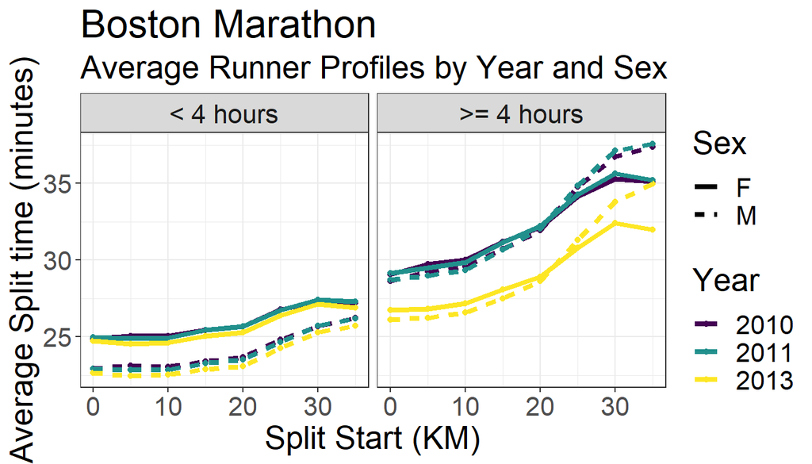

```r
bm_long %>%
  filter(split_start < 40 ) %>%
  mutate(four = ifelse(final < 4*60, "< 4 hours", ">= 4 hours")) %>%
  group_by(four, year, sex, split_start) %>%
  summarize(mean = mean(split_time, na.rm=TRUE), sd = sd(split_time, na.rm=TRUE)) %>%
  drop_na(four) %>%
ggplot(aes(x=split_start, y=mean, color = as.character(year), linetype=sex)) +
  geom_point() +
  geom_line(size = 1.5) +
  facet_wrap(~four) +
  xlab("Split Start (KM)") +
  ylab("Average Split time (minutes)") +
  labs(color="Year", linetype = "Sex") +
  ggtitle("Boston Marathon",
          subtitle = "Average Runner Profiles by Year and Sex") +
  theme_bw() +
  theme(text = element_text(size=20))
```

- There are differences between the profiles for runners who finish in under 4 hours compared to those who take over 4 hours (aside from just slower times).
- It appears that runners who take over 4 hours have split times that increase throughout the course, on average, more than for the runners who finish in under 4 hours.
- This implies we should restrict our attention to runners from our data who completed the race in over 4 hours.
- We will also exclude the 2013 runners who did not finish but they quit before the half-way point because this may not due to the bombings.

##### Below we define our data set to be used in building our prediction model.

```r
## Select runners for analysis
data0 <- bm %>%
  filter(final >= 4*60 | (is.na(final) & !is.na(HalfMar) & year == 2013))

nrow(data0)
```

```
## [1] 21941
```

##### Add an indicator, `dnf`, for the runners who did not finish the race in 2013.

```r
## Add indicator for 2013 non-finishers
data0 <- data0 %>%
  mutate(dnf = ifelse(is.na(final), TRUE, FALSE))

data0 %>%
  group_by(year, dnf) %>%
  summarize(n = n())
```

```
## # A tibble: 4 × 3
## # Groups:   year [3]
##    year dnf       n
##   <dbl> <lgl> <int>
## 1  2010 FALSE  7133
## 2  2011 FALSE  7668
## 3  2013 FALSE  1512
## 4  2013 TRUE   5628
```

- There are 5,628 runners from 2013 in our reduced data who did not finish the race.
- We will try to predict their finishing times using the remaining observations from `data0`.

##### Now let’s get our data in the longer form so it is easier to plot the profiles.

```r
data <- data0 %>%
  pivot_longer(cols= starts_with("K"), names_to="split", values_to="split_time", names_prefix="K") %>%
  separate(split, c("split_start","split_end")) %>%
  mutate(split_start = as.numeric(split_start),
         split_end = as.numeric(split_end))

data %>%
  print(width=Inf)
```

```
## # A tibble: 197,469 × 13
##    bib    year   age sex   StartHr StartMin HalfMar Age2014 final dnf
##    <chr> <dbl> <dbl> <chr>   <dbl>    <dbl>   <dbl>   <dbl> <dbl> <lgl>
##  1 27009  2013    53 M           9     0.03    260.      54    NA TRUE
##  2 27009  2013    53 M           9     0.03    260.      54    NA TRUE
##  3 27009  2013    53 M           9     0.03    260.      54    NA TRUE
##  4 27009  2013    53 M           9     0.03    260.      54    NA TRUE
##  5 27009  2013    53 M           9     0.03    260.      54    NA TRUE
##  6 27009  2013    53 M           9     0.03    260.      54    NA TRUE
##  7 27009  2013    53 M           9     0.03    260.      54    NA TRUE
##  8 27009  2013    53 M           9     0.03    260.      54    NA TRUE
##  9 27009  2013    53 M           9     0.03    260.      54    NA TRUE
## 10 21209  2013    59 M          10    41.9     193.      60    NA TRUE
##    split_start split_end split_time
##          <dbl>     <dbl>      <dbl>
##  1           0         5       51.2
##  2           5        10       54.3
##  3          10        15       63.0
##  4          15        20       72.2
##  5          20        25       NA
##  6          25        30       NA
##  7          30        35       NA
##  8          35        40       NA
##  9          40        NA       NA
## 10           0         5       42.4
## # ℹ 197,459 more rows
```

> Of the DNF’s, when did they stop the race?

```r
data %>%
  filter(dnf & is.na(split_time)) %>%
  group_by(bib) %>%
  slice_min(n=1, order_by=split_start) %>%
  ungroup() %>%
  group_by(split_start) %>%
  summarize(n = n(), Percent = round(n/5628*100, 1))
```

```
## # A tibble: 5 × 3
##   split_start     n Percent
##         <dbl> <int>   <dbl>
## 1          20    93     1.7
## 2          25    38     0.7
## 3          30   459     8.2
## 4          35   533     9.5
## 5          40  4505    80
```

- Notice that 80% of the runners nearly completed the race and only had the final 2.2 KM stretch to go.

#### Compare the average split times

We will begin by predicting the finishing times for those 2013 runners who only missed the final split K40-Fin.

Let’s visualize the average differences between the training sample and the 2013 runners up to their missing split.

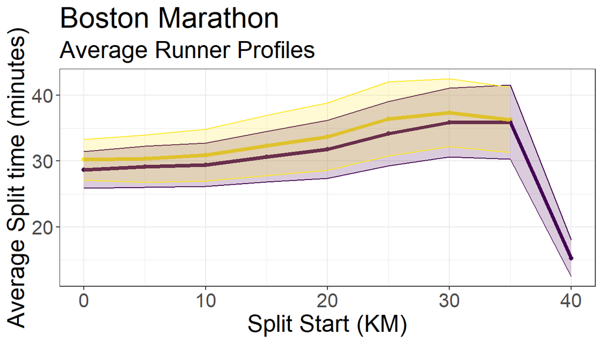

```r
data %>%
  # filter(split_start < 40 ) %>%
  group_by(dnf, split_start) %>%
  summarize(mean = mean(split_time, na.rm=TRUE), sd = sd(split_time, na.rm=TRUE)) %>%
  ggplot(aes(x=split_start, y=mean, color = dnf)) +
  geom_point(show.legend = FALSE) +
  geom_line(size = 1.5,show.legend = FALSE) +
  geom_ribbon(aes(ymin=mean-sd,ymax=mean+sd, fill=dnf), alpha=0.2, show.legend = FALSE) +
  xlab("Split Start (KM)") +
  ylab("Average Split time (minutes)") +
  # labs(color="Missing final split") +
  ggtitle("Boston Marathon",
          subtitle = "Average Runner Profiles") +
  theme_bw() +
  theme(text = element_text(size=20))
```

# Linear Regression Model

- There are a number of different approaches for carrying out the prediction of the finishing times for the runners who did not complete the 2013 Boston Marathon due to the bombings.
- The paper [*Completing the Results of the 2013 Boston Marathon*](https://journals.plos.org/plosone/article?id=10.1371/journal.pone.0093800) by Hammerling et al (2014) in PLOS ONE tries several approaches for carrying out the prediction task. For example, a couple of the methods are listed below.
  1. Linear regression
  2. Nearest Neighbor (to select the 200 runner profiles that are most similar to the 2013 runner that needs a predicted final time) + local linear regression

We will build several regression models using the runners in our reduced data set, `data`, who did finish the race using the equation below.

- The model will be built using a subset of $1:J$ splits to predict the finishing time:

$$y_i = \beta_0 + \sum_{j = 1}^J x_{ji}\beta_j + \varepsilon_i$$

- $y_i$ = the final time for runner $i$
- $J$ = number of available split times
- $x_{ji}$ = the available split time for runner $i$’s interval $j$
- $\varepsilon_i$ = random error for runner $i$, assumed to satisfy $E(\varepsilon_i)=0$, and the $\varepsilon_i$’s are considered uncorrelated with a constant variance of $\sigma^2$.

We will estimate the $\beta_j$’s using the `dnr = FALSE` data, and then predict the finishing times for the `dnr = TRUE` runners using the estimated $\beta_j$’s to fill in the missing values.

First we rename the variables corresponding to the intervals to make it a little easier to specify our models:

```r
data0 <- data0 %>%
  rename(k0 = `K0-5`,
         k5 = `K5-10`,
         k10 = `K10-15`,
         k15 = `K15-20`,
         k20 = `K20-25`,
         k25 = `K25-30`,
         k30 = `K30-35`,
         k35 = `K35-40`,
         k40 = `K40-Fin`)

## Data to fit our model
train <- data0 %>%
  filter(dnf == FALSE)%>%
  select(final, starts_with("k")) %>%
  mutate(index = row_number()) %>%
  select(index, everything())

## Data for prediction
dnf <- data0 %>%
  filter(dnf) %>%
  mutate(index = row_number()) %>%
  select(index, everything())
```

Below we fit five linear models.

Each linear model has a different drop-out point for the runners where we use the previous split times to estimate the final split time.

Let’s focus on the first model defined in the chunk below using the first 8 intervals:

$$y_i = \beta_0 + \sum_{j = 1}^8 x_{ij}\beta_j + \varepsilon_i = \beta_0 +
x_{i1}\beta_1 + \cdots + x_{i8}\beta_8 + \varepsilon_i$$

```r
fit35 <- lm(final~k0+k5+k10+k15+k20+k25+k30+k35, data = train)
summary(fit35)
```

```
##
## Call:
## lm(formula = final ~ k0 + k5 + k10 + k15 + k20 + k25 + k30 +
##     k35, data = train)
##
## Residuals:
##     Min      1Q  Median      3Q     Max
## -36.927  -0.706  -0.117   0.550 190.700
##
## Coefficients:
##             Estimate Std. Error t value Pr(>|t|)
## (Intercept) 2.736886   0.197320   13.87   <2e-16 ***
## k0          0.962112   0.014230   67.61   <2e-16 ***
## k5          1.035686   0.017374   59.61   <2e-16 ***
## k10         1.064902   0.016575   64.25   <2e-16 ***
## k15         0.994115   0.011858   83.83   <2e-16 ***
## k20         0.989423   0.008631  114.64   <2e-16 ***
## k25         1.010809   0.007653  132.07   <2e-16 ***
## k30         1.041826   0.006294  165.52   <2e-16 ***
## k35         1.258684   0.004486  280.60   <2e-16 ***
## ---
## Signif. codes:  0 '***' 0.001 '**' 0.01 '*' 0.05 '.' 0.1 ' ' 1
##
## Residual standard error: 2.209 on 16304 degrees of freedom
## Multiple R-squared:  0.9939, Adjusted R-squared:  0.9939
## F-statistic: 3.332e+05 on 8 and 16304 DF,  p-value: < 2.2e-16
```

- `fit35` is a linear model that uses all the split times except for the final 2.2 KM leg of the race.
- Notice that we have multiple covariates in this model. Earlier in the semester we only considered linear models with a single covariate. To include multiple covariates, we use the `lm()` function and add them to the right of the `~`.
- The summary of the results indicates which of the estimated slopes are statistically significantly different from 0.
- In `fit35`, all the estimated coefficients have very small p-values.
- Most of the estimated slopes are near 1. This makes sense because if we had included all of the intervals, the true model would be the sum of the interval times (so all the slopes would be 1).

Let’s take a peek at the residuals. Since we have multiple covariates, we will plot the predicted finishing times on the x-axis.

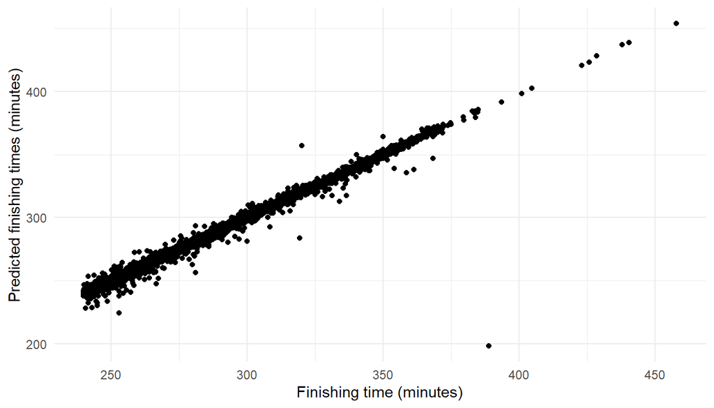

```r
## Predicted vs. observed final times
train %>%
  add_residuals(fit35) %>%
  add_predictions(fit35) %>%
  ggplot(aes(x = final, y=pred)) +
  geom_point() +
  xlab("Finishing time (minutes)") +
  ylab("Predicted finishing times (minutes)")
```

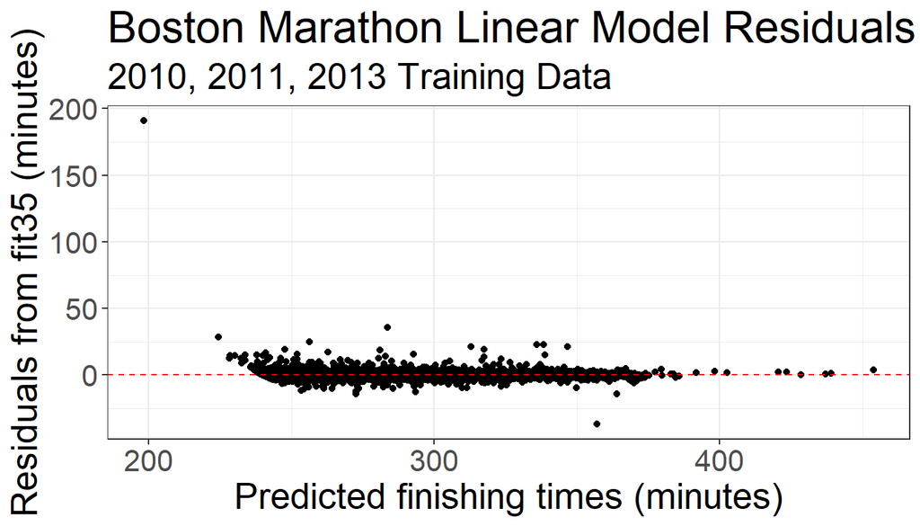

```r
## Residual plot
train %>%
  add_residuals(fit35) %>%
  add_predictions(fit35) %>%
  ggplot(aes(x = pred, y=resid)) +
  geom_point() +
  geom_hline(yintercept = 0, color = "red", linetype = "dashed") +
  # ylim(-30, 30) +
  xlab("Predicted finishing times (minutes)") +
  ylab("Residuals from fit35 (minutes)") +
  ggtitle("Boston Marathon Linear Model Residuals",
          subtitle = "2010, 2011, 2013 Training Data") +
  theme_bw() +
  theme(text = element_text(size=20))
```

```r
## Explore the large residual
train %>%
  add_residuals(fit35) %>%
  add_predictions(fit35) %>%
  arrange(desc(resid))
```

```
## # A tibble: 16,313 × 13
##    index final    k0    k5   k10   k15   k20   k25   k30   k35   k40 resid  pred
##    <int> <dbl> <dbl> <dbl> <dbl> <dbl> <dbl> <dbl> <dbl> <dbl> <dbl> <dbl> <dbl>
##  1 14707  389.  22.8  22.8  22.1  22.4  22.7  23.7  25.0  25.1 202.  191.   198.
##  2 13349  319.  27.4  27.9  28.5  29.4  30.3  30.2  33.4  56.2  56.2  35.9  284.
##  3 13894  253   22.4  22.5  22.4  22.5  22.4  23.3  26.6  45.4  45.4  28.5  224.
##  4  6787  281.  26.7  26.8  27.7  29.3  31.4  38.8  30.8  31.1  38.7  24.9  256.
##  5  9471  361.  40.1  40.1  40.1  40.1  40.1  40.1  40.1  40.1  40.1  23.1  338.
##  6 12942  359.  39.8  39.8  39.8  39.8  39.8  39.8  39.8  39.8  39.8  22.9  336.
##  7  9169  368.  32.2  32.7  38.6  42.1  51.8  57.3  37.9  37.9  37.9  21.5  347.
##  8 13566  334.  37.1  37.1  37.1  37.1  37.1  37.1  37.1  37.1  37.1  21.1  313.
##  9 14966  334.  37.1  37.1  37.1  37.1  37.1  37.1  37.1  37.1  37.1  21.1  313.
## 10  5529  267.  28.4  27.4  27.3  27.1  27.9  29.8  31.8  33.5  33.5  19.2  248.
## # ℹ 16,303 more rows
```

It looks like the residual is from a runner who had an unusual split in the final 2.2 km. The runner took 202 minutes to complete the final split, with an overall time of 389 minutes…this means over half their time was spent on about 5% of the total distance. Something unusual happened to this runner (maybe an injury?), so we can remove this runner and refit the model.

```r
## Remove the residual
train_2 = train %>%
  filter(index != 14707)
fit35_2 <- lm(final~k0+k5+k10+k15+k20+k25+k30+k35, data = train_2)
summary(fit35_2)
```

```
##
## Call:
## lm(formula = final ~ k0 + k5 + k10 + k15 + k20 + k25 + k30 +
##     k35, data = train_2)
##
## Residuals:
##     Min      1Q  Median      3Q     Max
## -37.106  -0.691  -0.101   0.559  35.832
##
## Coefficients:
##             Estimate Std. Error t value Pr(>|t|)
## (Intercept) 2.388872   0.145419   16.43   <2e-16 ***
## k0          0.968839   0.010485   92.40   <2e-16 ***
## k5          1.031566   0.012801   80.58   <2e-16 ***
## k10         1.069438   0.012213   87.57   <2e-16 ***
## k15         0.994234   0.008737  113.79   <2e-16 ***
## k20         0.989134   0.006359  155.54   <2e-16 ***
## k25         1.011377   0.005639  179.35   <2e-16 ***
## k30         1.042841   0.004638  224.86   <2e-16 ***
## k35         1.260896   0.003305  381.49   <2e-16 ***
## ---
## Signif. codes:  0 '***' 0.001 '**' 0.01 '*' 0.05 '.' 0.1 ' ' 1
##
## Residual standard error: 1.628 on 16303 degrees of freedom
## Multiple R-squared:  0.9967, Adjusted R-squared:  0.9967
## F-statistic: 6.148e+05 on 8 and 16303 DF,  p-value: < 2.2e-16
```

```r
## Minor changes to the estimated coefficients:
rbind(coef(fit35), coef(fit35_2))
```

```
##      (Intercept)        k0       k5      k10       k15       k20      k25
## [1,]    2.736886 0.9621118 1.035686 1.064902 0.9941146 0.9894226 1.010809
## [2,]    2.388872 0.9688389 1.031566 1.069438 0.9942339 0.9891335 1.011377
##           k30      k35
## [1,] 1.041826 1.258684
## [2,] 1.042841 1.260896
```

Now we can predict the finishing times for the runners from 2013 who did not finish the race, but completed all but the 40-Finish leg of the race.

First we need to select the runners that fit in this group:

```r
which_runners <- data %>%
  filter(dnf & is.na(split_time)) %>%
  group_by(bib) %>%
  slice_min(n=1, order_by=split_start) %>%
  filter(split_start == 40) %>% #only missing final split
  pull(bib)


test35 <- dnf %>%
  filter(bib %in% which_runners) %>%
  select(bib, starts_with("k"))
test35
```

```
## # A tibble: 4,505 × 10
##    bib      k0    k5   k10   k15   k20   k25   k30   k35   k40
##    <chr> <dbl> <dbl> <dbl> <dbl> <dbl> <dbl> <dbl> <dbl> <dbl>
##  1 21216  32.9  36.2  42.7  50.7  54.5  56.6  59.0  54.5    NA
##  2 23820  34.4  33.9  34.8  36.3  37.9  40.4  41.4  40.4    NA
##  3 23013  36    38.8  38.2  39.9  38.4  38.6  36.9  35.9    NA
##  4 26731  32.4  32.7  33.4  34.2  34.4  39.5  43.6  48.4    NA
##  5 26090  34.4  32.6  34.0  38.4  36.4  39.2  39.2  41.8    NA
##  6 26091  34.4  32.6  34.0  38.4  36.4  39.2  39.2  41.8    NA
##  7 23680  31.5  30.9  35.4  35.4  41.1  43.6  42.2  39.5    NA
##  8 23748  34.1  34.5  35.2  37.3  37.0  40.6  41.2  41.1    NA
##  9 21435  30.2  32.4  34.5  36.4  38    40.2  44.4  46.8    NA
## 10 23334  33.0  37.1  34.9  36.2  37.2  40.8  39.9  42.3    NA
## # ℹ 4,495 more rows
```

```r
test35 <- test35 %>%
  mutate(final = predict(fit35_2, test35),
         predict = TRUE)
test35
```

```
## # A tibble: 4,505 × 12
##    bib      k0    k5   k10   k15   k20   k25   k30   k35   k40 final predict
##    <chr> <dbl> <dbl> <dbl> <dbl> <dbl> <dbl> <dbl> <dbl> <dbl> <dbl> <lgl>
##  1 21216  32.9  36.2  42.7  50.7  54.5  56.6  59.0  54.5    NA  409. TRUE
##  2 23820  34.4  33.9  34.8  36.3  37.9  40.4  41.4  40.4    NA  317. TRUE
##  3 23013  36    38.8  38.2  39.9  38.4  38.6  36.9  35.9    NA  319. TRUE
##  4 26731  32.4  32.7  33.4  34.2  34.4  39.5  43.6  48.4    NA  318. TRUE
##  5 26090  34.4  32.6  34.0  38.4  36.4  39.2  39.2  41.8    NA  313. TRUE
##  6 26091  34.4  32.6  34.0  38.4  36.4  39.2  39.2  41.8    NA  313. TRUE
##  7 23680  31.5  30.9  35.4  35.4  41.1  43.6  42.2  39.5    NA  316. TRUE
##  8 23748  34.1  34.5  35.2  37.3  37.0  40.6  41.2  41.1    NA  318. TRUE
##  9 21435  30.2  32.4  34.5  36.4  38    40.2  44.4  46.8    NA  322. TRUE
## 10 23334  33.0  37.1  34.9  36.2  37.2  40.8  39.9  42.3    NA  319. TRUE
## # ℹ 4,495 more rows
```

Check if the predicted times seem reasonable compared to training data

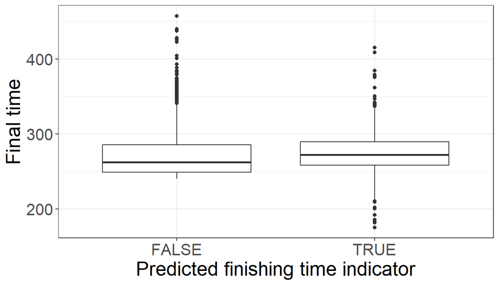

```r
pred35 = train %>%
  mutate(predict = FALSE) %>%
  bind_rows(test35)

ggplot(pred35, aes(x = predict, y = final)) +
  geom_boxplot() +
  xlab("Predicted finishing time indicator") +
  ylab("Final time") +
  theme_bw() +
  theme(text = element_text(size=20))
```

The two distributions *appear* reasonably consistent…can we detect differences in the mean of these distributions?

If we view these as two independent samples from our population of potential runners of the Boston Marathon, we can carry out a hypothesis test to see if we detect a difference between the mean finishing times using the samples defined above.

```r
### Training times
group1 = pred35 %>%
  filter(!predict) %>%
  pull(final)
n1 = length(group1)
n1
```

```
## [1] 16313
```

```r
### Predicted times
group2 = pred35 %>%
  filter(predict) %>%
  pull(final)
n2 = length(group2)
n2
```

```
## [1] 4505
```

```r
### Use t.test to compute a p-value
t.test(group1, group2)
```

```
##
##  Welch Two Sample t-test
##
## data:  group1 and group2
## t = -11.702, df = 9539, p-value < 2.2e-16
## alternative hypothesis: true difference in means is not equal to 0
## 95 percent confidence interval:
##  -5.228758 -3.728306
## sample estimates:
## mean of x mean of y
##  270.9636  275.4422
```

```r
### Manually compute the test statistic
tstat = (mean(group1) - mean(group2))/sqrt(var(group1)/n1 + var(group2)/n2)
tstat
```

```
## [1] -11.70164
```

```r
pt(tstat, t.test(group1, group2)$parameter)*2
```

```
## [1] 2.048369e-31
```

This test suggests there is a statistically significant difference between the mean of the predicted finishing times and the mean of the training finishing times. However, the estimated difference in the means is under 5 minutes. Is this practically significant for the population of runners who would take over 4 hours to complete the Boston Marathon?

Below we fit the remaining four linear models. These models can be used to predict the finishing times for the 2013 runners who dropped out after (i) the 35 KM mark, (ii) the 30 KM mark, (iii) the 25 KM mark, or (iv) the 20 KM mark.

```r
fit30 <- lm(final~k0+k5+k10+k15+k20+k25+k30, data = train_2)
summary(fit30)
```

```
##
## Call:
## lm(formula = final ~ k0 + k5 + k10 + k15 + k20 + k25 + k30, data = train_2)
##
## Residuals:
##      Min       1Q   Median       3Q      Max
## -131.685   -2.483   -0.682    1.688  127.045
##
## Coefficients:
##             Estimate Std. Error t value Pr(>|t|)
## (Intercept) 15.80433    0.44456   35.55   <2e-16 ***
## k0           0.85376    0.03302   25.86   <2e-16 ***
## k5           1.03885    0.04033   25.76   <2e-16 ***
## k10          0.99808    0.03847   25.94   <2e-16 ***
## k15          0.95556    0.02753   34.72   <2e-16 ***
## k20          0.99590    0.02004   49.71   <2e-16 ***
## k25          1.15212    0.01773   64.99   <2e-16 ***
## k30          1.97061    0.01244  158.39   <2e-16 ***
## ---
## Signif. codes:  0 '***' 0.001 '**' 0.01 '*' 0.05 '.' 0.1 ' ' 1
##
## Residual standard error: 5.129 on 16304 degrees of freedom
## Multiple R-squared:  0.9672, Adjusted R-squared:  0.9672
## F-statistic: 6.869e+04 on 7 and 16304 DF,  p-value: < 2.2e-16
```

```r
fit25 <- lm(final~k0+k5+k10+k15+k20+k25, data = train_2)
summary(fit25)
```

```
##
## Call:
## lm(formula = final ~ k0 + k5 + k10 + k15 + k20 + k25, data = train_2)
##
## Residuals:
##      Min       1Q   Median       3Q      Max
## -116.134   -4.720   -1.261    3.344  128.436
##
## Coefficients:
##             Estimate Std. Error t value Pr(>|t|)
## (Intercept) 34.70084    0.68232   50.86   <2e-16 ***
## k0           0.71300    0.05259   13.56   <2e-16 ***
## k5           0.91745    0.06425   14.28   <2e-16 ***
## k10          0.91946    0.06129   15.00   <2e-16 ***
## k15          0.93497    0.04386   21.32   <2e-16 ***
## k20          1.20791    0.03185   37.92   <2e-16 ***
## k25          2.77701    0.02304  120.55   <2e-16 ***
## ---
## Signif. codes:  0 '***' 0.001 '**' 0.01 '*' 0.05 '.' 0.1 ' ' 1
##
## Residual standard error: 8.172 on 16305 degrees of freedom
## Multiple R-squared:  0.9167, Adjusted R-squared:  0.9167
## F-statistic: 2.992e+04 on 6 and 16305 DF,  p-value: < 2.2e-16
```

```r
fit20 <- lm(final~k0+k5+k10+k15+k20, data = train_2)
summary(fit20)
```

```
##
## Call:
## lm(formula = final ~ k0 + k5 + k10 + k15 + k20, data = train_2)
##
## Residuals:
##      Min       1Q   Median       3Q      Max
## -180.717   -7.123   -1.816    5.247  124.299
##
## Coefficients:
##             Estimate Std. Error t value Pr(>|t|)
## (Intercept) 48.87143    0.92428  52.875  < 2e-16 ***
## k0           0.43282    0.07225   5.990 2.14e-09 ***
## k5           0.65145    0.08830   7.378 1.69e-13 ***
## k10          1.13075    0.08425  13.421  < 2e-16 ***
## k15          1.76835    0.05955  29.693  < 2e-16 ***
## k20          3.24437    0.03713  87.376  < 2e-16 ***
## ---
## Signif. codes:  0 '***' 0.001 '**' 0.01 '*' 0.05 '.' 0.1 ' ' 1
##
## Residual standard error: 11.24 on 16306 degrees of freedom
## Multiple R-squared:  0.8425, Adjusted R-squared:  0.8425
## F-statistic: 1.745e+04 on 5 and 16306 DF,  p-value: < 2.2e-16
```

```r
fit15 <- lm(final~k0+k5+k10+k15, data = train_2)
summary(fit15)
```

```
##
## Call:
## lm(formula = final ~ k0 + k5 + k10 + k15, data = train_2)
##
## Residuals:
##      Min       1Q   Median       3Q      Max
## -263.407   -9.083   -2.292    6.680  124.376
##
## Coefficients:
##             Estimate Std. Error t value Pr(>|t|)
## (Intercept) 56.12765    1.11538  50.321  < 2e-16 ***
## k0           0.09244    0.08742   1.057 0.290342
## k5           0.41580    0.10694   3.888 0.000101 ***
## k10          2.13407    0.10113  21.101  < 2e-16 ***
## k15          4.47415    0.06164  72.589  < 2e-16 ***
## ---
## Signif. codes:  0 '***' 0.001 '**' 0.01 '*' 0.05 '.' 0.1 ' ' 1
##
## Residual standard error: 13.62 on 16307 degrees of freedom
## Multiple R-squared:  0.7688, Adjusted R-squared:  0.7688
## F-statistic: 1.356e+04 on 4 and 16307 DF,  p-value: < 2.2e-16
```

- You can work on evaluating the residuals for these models and predicting the finishing times for the corresponding 2013 runners on your own if you like!
- Can you think of other variables to include in the linear model?